# Supervised Learning - Foundations Project: ReCell

## Preparation Information

- Developed and Analyzed by: Jerry Gonzalez
- Cohort: November 2023 - Group D

## Problem Statement

### Business Context

Buying and selling used phones and tablets used to be something that happened on a handful of online marketplace sites. But the used and refurbished device market has grown considerably over the past decade, and a new IDC (International Data Corporation) forecast predicts that the used phone market would be worth \$52.7bn by 2023 with a compound annual growth rate (CAGR) of 13.6% from 2018 to 2023. This growth can be attributed to an uptick in demand for used phones and tablets that offer considerable savings compared with new models.

Refurbished and used devices continue to provide cost-effective alternatives to both consumers and businesses that are looking to save money when purchasing one. There are plenty of other benefits associated with the used device market. Used and refurbished devices can be sold with warranties and can also be insured with proof of purchase. Third-party vendors/platforms, such as Verizon, Amazon, etc., provide attractive offers to customers for refurbished devices. Maximizing the longevity of devices through second-hand trade also reduces their environmental impact and helps in recycling and reducing waste. The impact of the COVID-19 outbreak may further boost this segment as consumers cut back on discretionary spending and buy phones and tablets only for immediate needs.

### Objective

The rising potential of this comparatively under-the-radar market fuels the need for an ML-based solution to develop a dynamic pricing strategy for used and refurbished devices. ReCell, a startup aiming to tap the potential in this market, has hired you as a data scientist. They want you to analyze the data provided and build a linear regression model to predict the price of a used phone/tablet and identify factors that significantly influence it.

### Data Description

The data contains the different attributes of used/refurbished phones and tablets. The data was collected in the year 2021. The detailed data dictionary is given below.

- brand_name: Name of manufacturing brand
- os: OS on which the device runs
- screen_size: Size of the screen in cm
- 4g: Whether 4G is available or not
- 5g: Whether 5G is available or not
- main_camera_mp: Resolution of the rear camera in megapixels
- selfie_camera_mp: Resolution of the front camera in megapixels
- int_memory: Amount of internal memory (ROM) in GB
- ram: Amount of RAM in GB
- battery: Energy capacity of the device battery in mAh
- weight: Weight of the device in grams
- release_year: Year when the device model was released
- days_used: Number of days the used/refurbished device has been used
- normalized_new_price: Normalized price of a new device of the same model in euros
- normalized_used_price: Normalized price of the used/refurbished device in euros

### Problem Definition

The objective is to build a linear regression model to help predict the prices of reburbished phones and tablets. This will be done by analyzing a comprehenive data set consisting of various device attributes such as brand name, OS, screen size, camera resolution, etc. The final model will identify those key attributes that significantly influence the pricing dynamics of these used devices.

By gaining insights in this dynamic pricing, ReCell can dynamically adjust pricing in response to market flucuations, customer preferences, and changes in competitive landscapes. It is anticipated that this dynamic pricing model will give ReCell a competive edge, as a startup, to penetrate and become profitable in the used device industry.

### Questions

1. What are the key attributes/features that significantly influence the pricing dynamics of used devices?
2. What is the linear regression formula to help predict the pricing of used devices?
3. Based on actionable insights and metrics, how good is the model in predicting prices for used devices?

## Importing necessary libraries

```python
# this will help in making the Python code more structured automatically (good coding practice)
#%load_ext nb_black

# Libraries to help with reading and manipulating data
import numpy as np
import pandas as pd

# Libraries to help with data visualization
import matplotlib.pyplot as plt
import seaborn as sns

sns.set()

# split the data into train and test
from sklearn.model_selection import train_test_split

# to build linear regression_model
from sklearn.linear_model import LinearRegression

# to check model performance
from sklearn.metrics import mean_absolute_error, mean_squared_error, r2_score

# to build linear regression_model using statsmodels
import statsmodels.api as sm

# to compute VIF
from statsmodels.stats.outliers_influence import variance_inflation_factor

# import warnings to suppress them
import warnings
```

### Initialize some basic Panda configurations

```python
# removing the limit for the number of displayed columns
pd.set_option("display.max_columns", None) # To set column limits replace None with a number
# setting the limit for the number of displayed rows
pd.set_option("display.max_rows", 25) # To set row limits replace None with a number
# setting the precision of floating numbers to 2 decimal points
pd.set_option("display.float_format", lambda x: "%.6f" % x)
```

### Load some useful functions

```python
# Purpose: Calculate various discrete statistical values for a specific column in a DataFrame
#
# Prerequisites:
#    Requires the developer to only send data that discrete statistics can safely be calculated for.
#    This function would require more extensive data validation checks and more robust exception handling.
#
# Inputs
#    data   : DataFrame object containing rows and columns of data
#    feature: str representing the column name to run statistics on
#
def calculate_statistics (data, feature):

    # Only calculate and print statistics if the feature is a single column string name and data is a DataFrame
    if isinstance(data,pd.DataFrame) and type(feature) == str:

        # For future, would like to use Describe to pull data types for each column
        # Then only perform the calculations and prints if of type Int64 or Float64

        # Calculate and print various discrete statistical values
        print(f"Discrete Statistics for {feature}\n")
        print(f"Mean              : {data[feature].mean():.6f}")
        print(f"Mode              : {data[feature].mode()[0]}")
        print(f"Median            : {data[feature].median()}")
        print(f"Min               : {data[feature].min()}")
        print(f"Max               : {data[feature].max()}")
        print(f"Standard Deviation: {data[feature].std():.6f}")
        print(f"Percentiles       : \n{data[feature].quantile([.25,.50,.75])}")
```

```python
# Purpose: Create histogram plot to visualize the distribution of continuous numerical data
#      by dividing the data into bins and displaying the frequency of observations within each bin.
#      Histogram is useful for understanding the underlining distribution, shape, central tendency,
#      and spread of the data.
#
# Inputs:
#
#      input_data: DataFrame object containing rows and columns of data
#      feature: str representing the column name to plot a histogram for
#      in_kde: boolean value; True: plot the kde density line; False: do not plot the kde line
#

def histogram(input_data, feature, in_kde=True):

    # Only proceed if the feature is a single column string name and data is a DataFrame
    if isinstance(input_data,pd.DataFrame) and type(feature) == str:

        plt.figure(figsize=(10, 6))

        #stores the x axis left and right buffer size
        buffer=5

        #set the x limits based on the minimum and maximum values for x-axis feature
        xmin_value = int(input_data[feature].min())
        xmax_value = int(input_data[feature].max())
        plt.xlim(xmin_value-buffer,xmax_value+buffer)

        #plot the histogram using the buffersize
        sns.histplot(data=input_data, x=feature, kde=in_kde);

        #set the title, x and y labels
        plt.title('Histogram of '+ feature)
        plt.xlabel(feature)
        plt.ylabel('Frequency')

        plt.show()
```

```python
# Purpose: Create a Boxplot, for a particular column/feature, to visually summarize the distribution
#      of a continuous numerical variable and to identify potential outliers within the data.
#
# Inputs:
#
#      input_data: DataFrame object containing rows and columns of data
#      feature: str representing the column name to plot a count plot graph for
#      in_showfliers: True (show the outliers); False (do not show outliers)
#      in_showlabels: True (show boxplot labels for Max,Q3,Median,Q1, and Min); False (do not show labels)
#

def boxplot(input_data,feature, in_showfliers=False, in_showlabels=True):

    # Only proceed if data is a DataFrame
    if isinstance(input_data,pd.DataFrame):

        plt.figure(figsize=(10, 6))

        ax = sns.boxplot(
            data=input_data, x=feature, showmeans=True, color="violet"
        )  # boxplot will be created and a triangle will indicate the mean value of the column

        plt.title('Boxplot of '+ feature)
        plt.xlabel(feature)

        plt.show()
```

```python
# Purpose: Create a countplot; used to visualize counts for categorical data
#
# Inputs:
#
#     input_data: DataFrame object containing rows and columns of data
#     feature: str representing the column name to plot a count plot graph for (category column)
#     show_perc: value from [0,1] indicating the top % values to show in the countplot
#     label_count: True (show count labels); False (show percentage labels)
#
def countplot (input_data, feature, show_perc=1.0, label_count=True):
    if isinstance(input_data,pd.DataFrame) and type(feature) == str:

        #Set the figure size. However, revist this later to see if there is a robust way to increase the
        #figure size based on the number of x-axis labels.
        plt.figure(figsize=(10, 6))

        #Perform a total counts, which sorts the list in descending order. Then grab the list of columns
        order_cols = input_data[feature].value_counts().index

        #Use the percentage value to determine how many of the top columns to show
        num_to_show = int(len(order_cols)*show_perc)

        #Grab the top columns to show in the count plot
        cols_to_show = input_data[feature].value_counts().nlargest(num_to_show).index

        #plot the top columns
        cp=sns.countplot(data=input_data,x=feature,order=cols_to_show)

        #rotate x labels for better readability
        plt.xticks(rotation=90)

        #set the title
        plt_title = f"Countplot for the top {show_perc*100}% {feature} values"
        plt.title(plt_title)

        # Apply some simple label formatting; remove the underscores and replace with a blank space
        cp.set_xlabel(feature.replace('_', ' ').title(), fontsize=15)

        #show values for each bar/patch. The labels will either be numerical values or percentages.
        for p in cp.patches:

            total_values = len(input_data[feature])

            #show count labels
            if label_count == True:
                label = p.get_height()
            else:
                # show percentage label
                label = "{:.1f}%".format(100 * p.get_height() / total_values)

            cp.annotate(
                label,
                (p.get_x()+p.get_width()/2.,p.get_height()),
                ha='center',
                va='center',
                xytext=(0,5), # set the label offset above the bar
                textcoords='offset points'
            )

        plt.show()
```

```python
# Purpose: Create Boxplot for multiple variables (x being a categorical value)
#
# Inputs:
#
#     in_data: DataFrame object containing rows and columns of data
#     x_feature: str representing the column name for the x-axis (categorical data)
#     y_feature: str representing the column name for the y-axis
#
def multi_boxplot (in_data, x_feature, y_feature):

    # Only proceed if the features is a single column string name and data is a DataFrame
    if isinstance(in_data,pd.DataFrame) and type(x_feature) == str and type(y_feature) == str:

        # visualizing the relationship between two featgures
        plt.figure(figsize=(12, 5))
        sns.boxplot(data=df, x=x_feature, y=y_feature, showmeans=True)
        plt.xticks(fontsize=15)
        plt.yticks(fontsize=15)
        plt.xticks(rotation='vertical')
        plt.xlabel(x_feature, fontsize=15)
        plt.ylabel(y_feature, fontsize=15);

        plt.show()
```

```python
# Purpose: Create a heatmap which supports multivariate analysis of 2+ numerical features. Heatmaps are
#     useful for identifying correlations between 2 or more variables.
#
# Inputs:
#
#     input_data: DataFrame object containing rows and columns of data
#
def heatmap (input_data):
    if isinstance(input_data,pd.DataFrame): #and type(feature) == str:
        plt.figure(figsize=(10,8))

        # Select only the numerical columns
        numeric_columns = input_data.select_dtypes(include=np.number)

        sns.heatmap(numeric_columns.corr(),annot=True,cmap='Spectral',vmin=-1,vmax=1)
        plt.show()
```

```python
# Purpose: To treat outliers by clipping them to the lower and upper whisker
#
# Inputs:
#     df: Dataframe
#     col: Feature that has outliers to treat
#
# Note: This procedure is being utilized from GreatLearning; Week 4 (Hands_on_Notebook_ExploratoryDataAnalysis)
def treat_outliers(df, col):
    """
    treats outliers in a variable
    col: str, name of the numerical variable
    df: dataframe
    col: name of the column
    """
    Q1 = df[col].quantile(0.25)  # 25th quantile
    Q3 = df[col].quantile(0.75)  # 75th quantile
    IQR = Q3 - Q1                # Inter Quantile Range (75th perentile - 25th percentile)
    lower_whisker = Q1 - 1.5 * IQR
    upper_whisker = Q3 + 1.5 * IQR

    # all the values smaller than lower_whisker will be assigned the value of lower_whisker
    # all the values greater than upper_whisker will be assigned the value of upper_whisker
    # the assignment will be done by using the clip function of NumPy
    df[col] = np.clip(df[col], lower_whisker, upper_whisker)

    return df
```

## Loading the dataset

```python
# loading data
df = pd.read_csv('./used_device_data.csv')
```

## Data Overview

- Observations
  - Viewing the first and last few rows of the dataset
  - Checking the shape of the dataset
  - Getting the statistical summary for the variables
- Sanity checks
  - Check for missing values
  - Check for duplicates

```python
# Verify the data file was read correctly by displaying the first five rows.
df.head()
```

|  | brand_name | os | screen_size | 4g | 5g | main_camera_mp | selfie_camera_mp | int_memory | ram | battery | weight | release_year | days_used | normalized_used_price | normalized_new_price |
| --- | --- | --- | --- | --- | --- | --- | --- | --- | --- | --- | --- | --- | --- | --- | --- |
| 0 | Honor | Android | 14.500000 | yes | no | 13.000000 | 5.000000 | 64.000000 | 3.000000 | 3020.000000 | 146.000000 | 2020 | 127 | 4.307572 | 4.715100 |
| 1 | Honor | Android | 17.300000 | yes | yes | 13.000000 | 16.000000 | 128.000000 | 8.000000 | 4300.000000 | 213.000000 | 2020 | 325 | 5.162097 | 5.519018 |
| 2 | Honor | Android | 16.690000 | yes | yes | 13.000000 | 8.000000 | 128.000000 | 8.000000 | 4200.000000 | 213.000000 | 2020 | 162 | 5.111084 | 5.884631 |
| 3 | Honor | Android | 25.500000 | yes | yes | 13.000000 | 8.000000 | 64.000000 | 6.000000 | 7250.000000 | 480.000000 | 2020 | 345 | 5.135387 | 5.630961 |
| 4 | Honor | Android | 15.320000 | yes | no | 13.000000 | 8.000000 | 64.000000 | 3.000000 | 5000.000000 | 185.000000 | 2020 | 293 | 4.389995 | 4.947837 |

```python
# Verify the entire data file was read correctly by displaying the last five rows.
df.tail()
```

|  | brand_name | os | screen_size | 4g | 5g | main_camera_mp | selfie_camera_mp | int_memory | ram | battery | weight | release_year | days_used | normalized_used_price | normalized_new_price |
| --- | --- | --- | --- | --- | --- | --- | --- | --- | --- | --- | --- | --- | --- | --- | --- |
| 3449 | Asus | Android | 15.340000 | yes | no | NaN | 8.000000 | 64.000000 | 6.000000 | 5000.000000 | 190.000000 | 2019 | 232 | 4.492337 | 6.483872 |
| 3450 | Asus | Android | 15.240000 | yes | no | 13.000000 | 8.000000 | 128.000000 | 8.000000 | 4000.000000 | 200.000000 | 2018 | 541 | 5.037732 | 6.251538 |
| 3451 | Alcatel | Android | 15.800000 | yes | no | 13.000000 | 5.000000 | 32.000000 | 3.000000 | 4000.000000 | 165.000000 | 2020 | 201 | 4.357350 | 4.528829 |
| 3452 | Alcatel | Android | 15.800000 | yes | no | 13.000000 | 5.000000 | 32.000000 | 2.000000 | 4000.000000 | 160.000000 | 2020 | 149 | 4.349762 | 4.624188 |
| 3453 | Alcatel | Android | 12.830000 | yes | no | 13.000000 | 5.000000 | 16.000000 | 2.000000 | 4000.000000 | 168.000000 | 2020 | 176 | 4.132122 | 4.279994 |

#### Observation(s):

- Head and Tail functions successfully show the file was read in correctly.
- Notice there is a NaN in the tail output. This is a clear indication some level of data cleanup will be required.

```python
# Print out the number of rows and columns in the data file.
df.shape
print(f"There are {df.shape[0]} rows and {df.shape[1]} columns.")
```

```
There are 3454 rows and 15 columns.
```

```python
# Print out basic information on the data file.
df.info()
```

```
<class 'pandas.core.frame.DataFrame'>
RangeIndex: 3454 entries, 0 to 3453
Data columns (total 15 columns):
 #   Column                 Non-Null Count  Dtype
---  ------                 --------------  -----
 0   brand_name             3454 non-null   object
 1   os                     3454 non-null   object
 2   screen_size            3454 non-null   float64
 3   4g                     3454 non-null   object
 4   5g                     3454 non-null   object
 5   main_camera_mp         3275 non-null   float64
 6   selfie_camera_mp       3452 non-null   float64
 7   int_memory             3450 non-null   float64
 8   ram                    3450 non-null   float64
 9   battery                3448 non-null   float64
 10  weight                 3447 non-null   float64
 11  release_year           3454 non-null   int64
 12  days_used              3454 non-null   int64
 13  normalized_used_price  3454 non-null   float64
 14  normalized_new_price   3454 non-null   float64
dtypes: float64(9), int64(2), object(4)
memory usage: 404.9+ KB
```

#### Observation(s)

- brand_name, os, 4g, and 5g are object types.
- release_year and days_used are int64 types.
- The remaining nine columns are all of type float64.
- Confirms 3454 rows were read in.
- main_camera_mp, selfie_camera_mp, int_memory, ram, battery, and weight are all missing values.
  - Indicates that some data preprocessing is required before model building can commence.

```python
# Print out some basic discrete statistics on the ABTest data
df.describe(include='all').T
```

|  | count | unique | top | freq | mean | std | min | 25% | 50% | 75% | max |
| --- | --- | --- | --- | --- | --- | --- | --- | --- | --- | --- | --- |
| brand_name | 3454 | 34 | Others | 502 | NaN | NaN | NaN | NaN | NaN | NaN | NaN |
| os | 3454 | 4 | Android | 3214 | NaN | NaN | NaN | NaN | NaN | NaN | NaN |
| screen_size | 3454.000000 | NaN | NaN | NaN | 13.713115 | 3.805280 | 5.080000 | 12.700000 | 12.830000 | 15.340000 | 30.710000 |
| 4g | 3454 | 2 | yes | 2335 | NaN | NaN | NaN | NaN | NaN | NaN | NaN |
| 5g | 3454 | 2 | no | 3302 | NaN | NaN | NaN | NaN | NaN | NaN | NaN |
| main_camera_mp | 3275.000000 | NaN | NaN | NaN | 9.460208 | 4.815461 | 0.080000 | 5.000000 | 8.000000 | 13.000000 | 48.000000 |
| selfie_camera_mp | 3452.000000 | NaN | NaN | NaN | 6.554229 | 6.970372 | 0.000000 | 2.000000 | 5.000000 | 8.000000 | 32.000000 |
| int_memory | 3450.000000 | NaN | NaN | NaN | 54.573099 | 84.972371 | 0.010000 | 16.000000 | 32.000000 | 64.000000 | 1024.000000 |
| ram | 3450.000000 | NaN | NaN | NaN | 4.036122 | 1.365105 | 0.020000 | 4.000000 | 4.000000 | 4.000000 | 12.000000 |
| battery | 3448.000000 | NaN | NaN | NaN | 3133.402697 | 1299.682844 | 500.000000 | 2100.000000 | 3000.000000 | 4000.000000 | 9720.000000 |
| weight | 3447.000000 | NaN | NaN | NaN | 182.751871 | 88.413228 | 69.000000 | 142.000000 | 160.000000 | 185.000000 | 855.000000 |
| release_year | 3454.000000 | NaN | NaN | NaN | 2015.965258 | 2.298455 | 2013.000000 | 2014.000000 | 2015.500000 | 2018.000000 | 2020.000000 |
| days_used | 3454.000000 | NaN | NaN | NaN | 674.869716 | 248.580166 | 91.000000 | 533.500000 | 690.500000 | 868.750000 | 1094.000000 |
| normalized_used_price | 3454.000000 | NaN | NaN | NaN | 4.364712 | 0.588914 | 1.536867 | 4.033931 | 4.405133 | 4.755700 | 6.619433 |
| normalized_new_price | 3454.000000 | NaN | NaN | NaN | 5.233107 | 0.683637 | 2.901422 | 4.790342 | 5.245892 | 5.673718 | 7.847841 |

#### Observation

- There are 34 unique brand_name values with **Others** occurring 502 times out of 3454.
- There are four unique os values with **Android** occurring 3214 times out of 3454.
- There are two unique 4g values with **yes** occurring 2335 times out of 3454.
- There are two unique 5g values with **no** occurring 3302 times out of 3454.
- The average screen_size is 13.71 cm (5.4 in) with a standard deviation of 3.81. The screen_size data appears to be righ skewed. Verify during univariate analysis.
- The average main camera resolution is 9.46 mp with a standard deviation of 4.82 mp.
- The average selfie camera resolution is 6.55 mp with a standard deviation of 6.97 mp.
- The average ram is 4.04 GB.
- The average release year is close to 2016 with a maximum release year of 2020.
- The average number of days used is 674.87 days (1.85 years).

#### Check for Missing Values

```python
# Check for missing values.
df.isnull().sum()
```

```
brand_name                 0
os                         0
screen_size                0
4g                         0
5g                         0
main_camera_mp           179
selfie_camera_mp           2
int_memory                 4
ram                        4
battery                    6
weight                     7
release_year               0
days_used                  0
normalized_used_price      0
normalized_new_price       0
dtype: int64
```

#### Observation

- main_camera_mp, selfie_camera_mp, int_memory, ram, battery, and weight are all missing values.

#### Check for Duplicate Values

```python
# Check for duplicate values
df.nunique()
```

```
brand_name                 34
os                          4
screen_size               142
4g                          2
5g                          2
main_camera_mp             41
selfie_camera_mp           37
int_memory                 15
ram                        12
battery                   324
weight                    555
release_year                8
days_used                 924
normalized_used_price    3094
normalized_new_price     2988
dtype: int64
```

#### Observation

- brand_name, os, 4g, and 5g are all category type of data and is understandable for them to have duplicate values.
- It is also not out of the ordinary for the remainder of the number fields to also have duplicate values. For example, screen size, ram, battery, weight, release year, etc have have limited values to select from.

## Exploratory Data Analysis (EDA)

- EDA is an important part of any project involving data.
- It is important to investigate and understand the data better before building a model with it.
- A few questions have been mentioned below which will help you approach the analysis in the right manner and generate insights from the data.
- A thorough analysis of the data, in addition to the questions mentioned below, should be done.

**Questions**:

1. What does the distribution of normalized used device prices look like?
2. What percentage of the used device market is dominated by Android devices?
3. The amount of RAM is important for the smooth functioning of a device. How does the amount of RAM vary with the brand?
4. A large battery often increases a device's weight, making it feel uncomfortable in the hands. How does the weight vary for phones and tablets offering large batteries (more than 4500 mAh)?
5. Bigger screens are desirable for entertainment purposes as they offer a better viewing experience. How many phones and tablets are available across different brands with a screen size larger than 6 inches?
6. A lot of devices nowadays offer great selfie cameras, allowing us to capture our favorite moments with loved ones. What is the distribution of devices offering greater than 8MP selfie cameras across brands?
7. Which attributes are highly correlated with the normalized price of a used device?

## Univariate Analysis

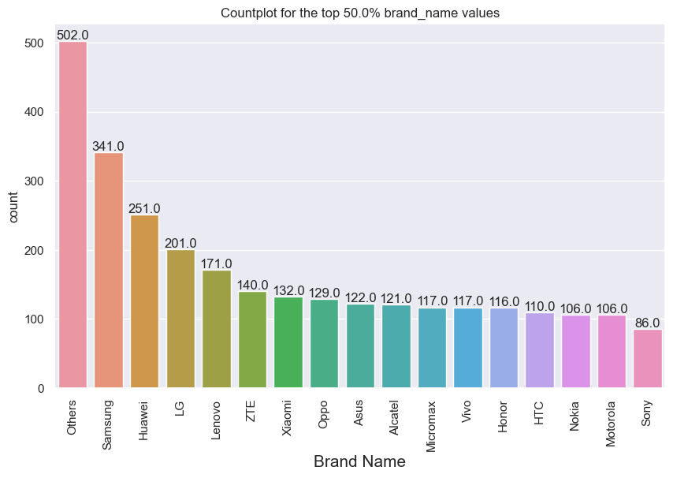

```
Number of brand names: 34
```

```python
# brand_name field univariate analysis

#Create histogram plot for the top groups
countplot(df,'brand_name',show_perc=.5,label_count=True)

#Print the total number of unique restaurants
print(f"Number of brand names: {df['brand_name'].nunique()}")
```

#### Observation

- The top five non-Other brands are: Samsung, Huawei, LG, Lenovo, and ZTE.

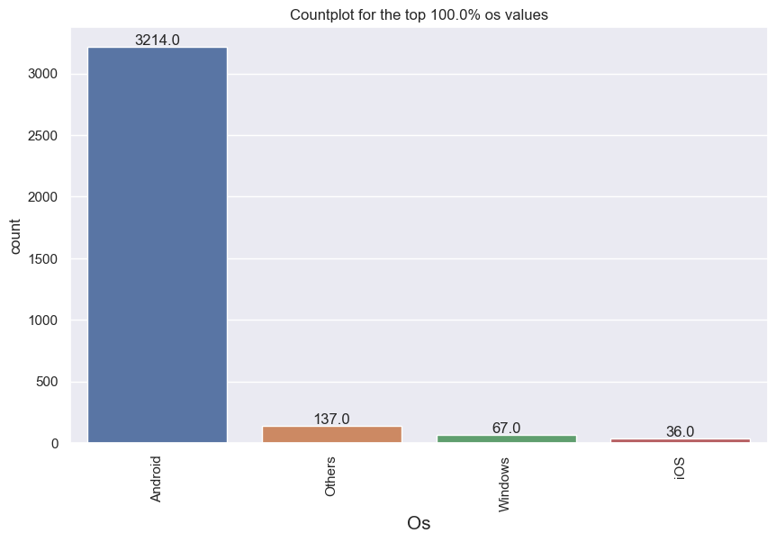

```
Number of OSes: 4
```

```python
# os field univariate analysis

#Create histogram plot for the top groups
countplot(df,'os',show_perc=1.0,label_count=True)

#Print the total number of unique restaurants
print(f"Number of OSes: {df['os'].nunique()}")
```

#### Observation

- There are four OS categories: Android, Windows, iOS, and Others
- Android has the largest number of entries in the data set with 3214.

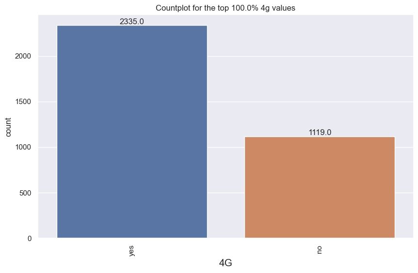

```
Number of 4Gs: 2
```

```python
# 4g field univariate analysis

#Create histogram plot for the top groups
countplot(df,'4g',show_perc=1.0,label_count=True)

#Print the total number of unique restaurants
print(f"Number of 4Gs: {df['4g'].nunique()}")
```

#### Observation

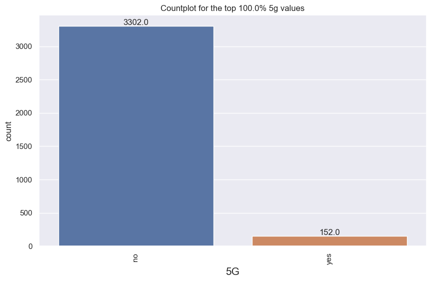

```
Number of 5Gs: 2
```

```python
# 5g field univariate analysis

#Create histogram plot for the top groups
countplot(df,'5g',show_perc=1.0,label_count=True)

#Print the total number of unique restaurants
print(f"Number of 5Gs: {df['5g'].nunique()}")
```

#### Observation

- The are two 5G values: yes and no
- Only 152 devices support 5G.

```
Discrete Statistics for screen_size

Mean              : 13.713115
Mode              : 12.7
Median            : 12.83
Min               : 5.08
Max               : 30.71
Standard Deviation: 3.805280
Percentiles       :
0.250000   12.700000
0.500000   12.830000
0.750000   15.340000
Name: screen_size, dtype: float64
```

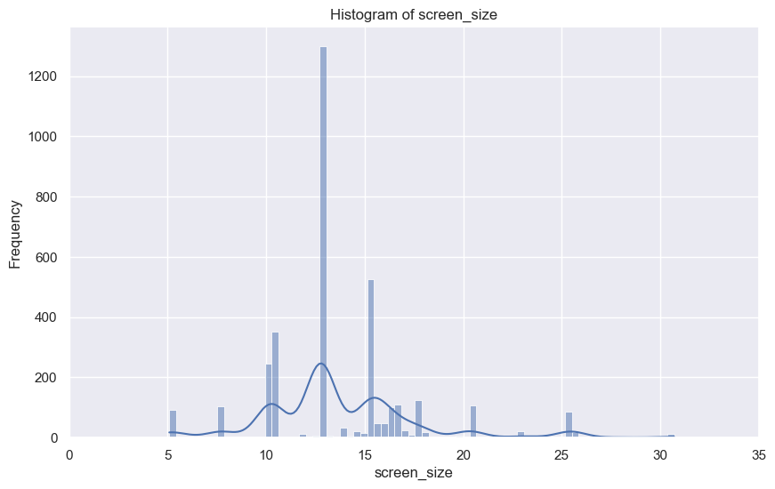

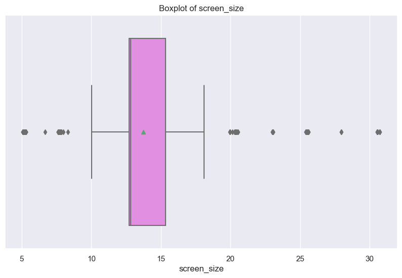

```python
# screen_size field univariate analysis
selected_column = 'screen_size'

#calculate univariate statistics
calculate_statistics(df,selected_column)

#show histogram for screen_size
histogram(df, selected_column)

#show boxplot for screen_size
boxplot(df,selected_column,in_showfliers=True,in_showlabels=False)
```

#### Observation

```
Discrete Statistics for main_camera_mp

Mean              : 9.460208
Mode              : 13.0
Median            : 8.0
Min               : 0.08
Max               : 48.0
Standard Deviation: 4.815461
Percentiles       :
0.250000    5.000000
0.500000    8.000000
0.750000   13.000000
Name: main_camera_mp, dtype: float64
```

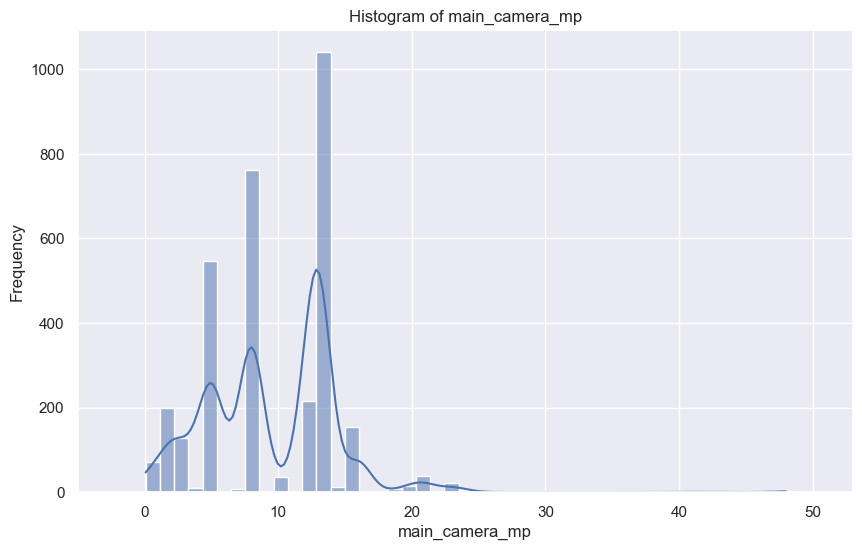

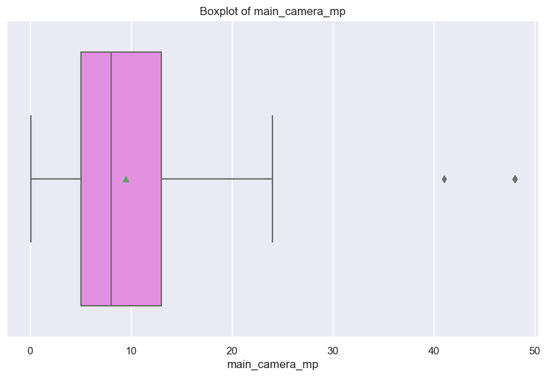

```python
# main_camera_mp field univariate analysis
selected_column = 'main_camera_mp'

#calculate univariate statistics
calculate_statistics(df,selected_column)

#show histogram for main_camera_mp
histogram(df, selected_column)

#show boxplot for main_camera_mp
boxplot(df,selected_column,in_showfliers=True,in_showlabels=False)
```

#### Observation

- The average main_camera_mp resolution is 9.460208 mp with a standard deviation of 4.815461 mp.
- There are some outliers above the maximum value line.

```
Discrete Statistics for selfie_camera_mp

Mean              : 6.554229
Mode              : 5.0
Median            : 5.0
Min               : 0.0
Max               : 32.0
Standard Deviation: 6.970372
Percentiles       :
0.250000   2.000000
0.500000   5.000000
0.750000   8.000000
Name: selfie_camera_mp, dtype: float64
```

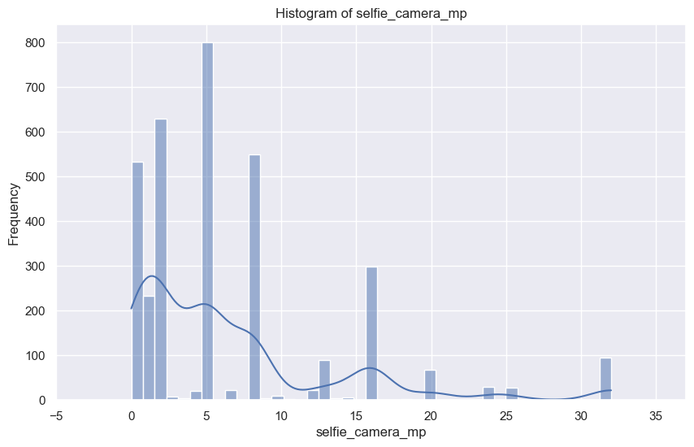

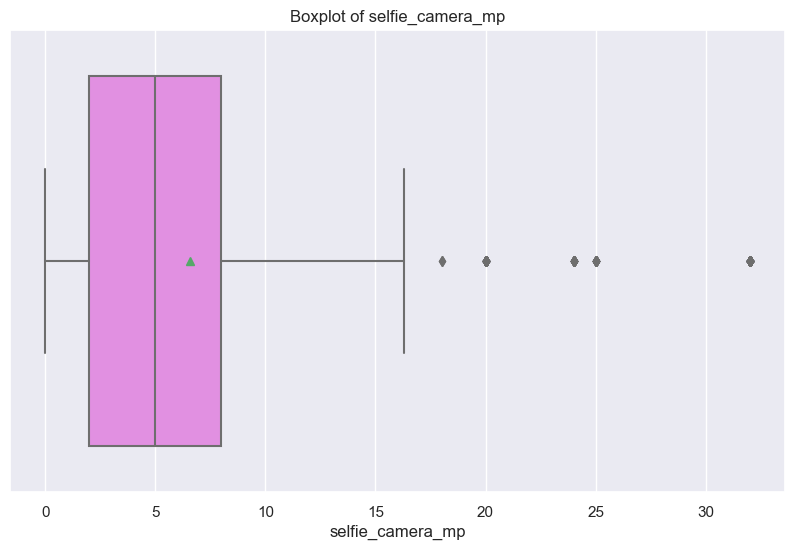

```python
# selfie_camera_mp field univariate analysis
selected_column = 'selfie_camera_mp'

#calculate univariate statistics
calculate_statistics(df,selected_column)

#show histogram for selfie_camera_mp
histogram(df, selected_column)

#show boxplot for selfie_camera_mp
boxplot(df,selected_column,in_showfliers=True,in_showlabels=False)
```

#### Observation

- The average selfie_camera_mp resolution is 6.554229 mp with a standard deviation of 6.970372 mp.
- The minimum selfie_camera_mp is 0 mp; indicating some devices are not equiped with a selfie camera.
- The maximum selfie_camera_mp = 32 mp.
- There are some outliers above the maximum value line.

```
Discrete Statistics for int_memory

Mean              : 54.573099
Mode              : 16.0
Median            : 32.0
Min               : 0.01
Max               : 1024.0
Standard Deviation: 84.972371
Percentiles       :
0.250000   16.000000
0.500000   32.000000
0.750000   64.000000
Name: int_memory, dtype: float64
```

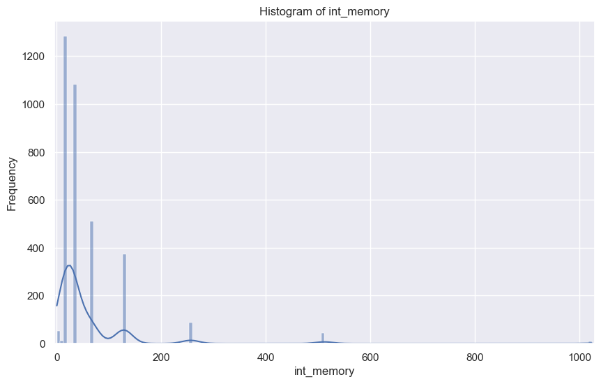

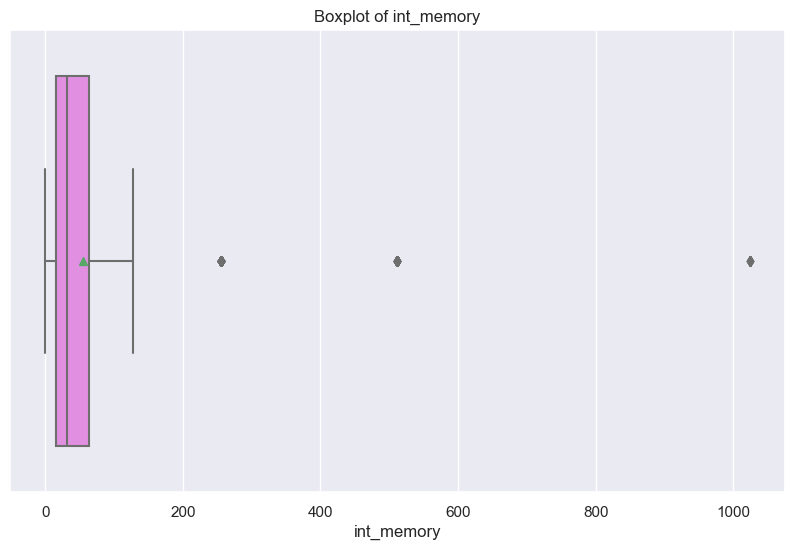

```python
# int_memory field univariate analysis
selected_column = 'int_memory'

#calculate univariate statistics
calculate_statistics(df,selected_column)

#show histogram for int_memory
histogram(df, selected_column)

#show boxplot for int_memory
boxplot(df,selected_column,in_showfliers=True,in_showlabels=False)
```

#### Observation

- The average int_memory ROM is 54.573099 GB with a standard deviation of 84.972371 GB.
- The minimum int_memory is 0.01 GB.
- The maximum int_memory = 1024.0 GB.
- Approximately, 75% of the devices have 64.00 GB or less of ROM. There are some outliers above the maximum value line.

```
Discrete Statistics for ram

Mean              : 4.036122
Mode              : 4.0
Median            : 4.0
Min               : 0.02
Max               : 12.0
Standard Deviation: 1.365105
Percentiles       :
0.250000   4.000000
0.500000   4.000000
0.750000   4.000000
Name: ram, dtype: float64
```

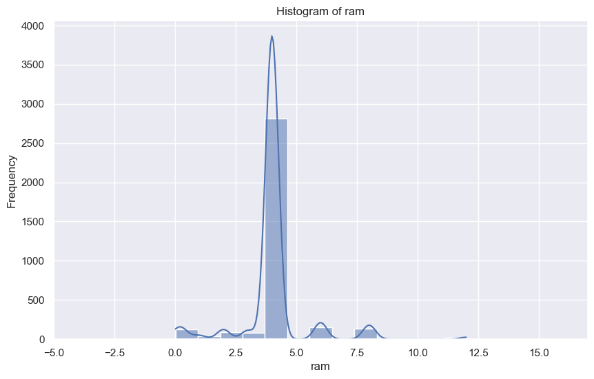

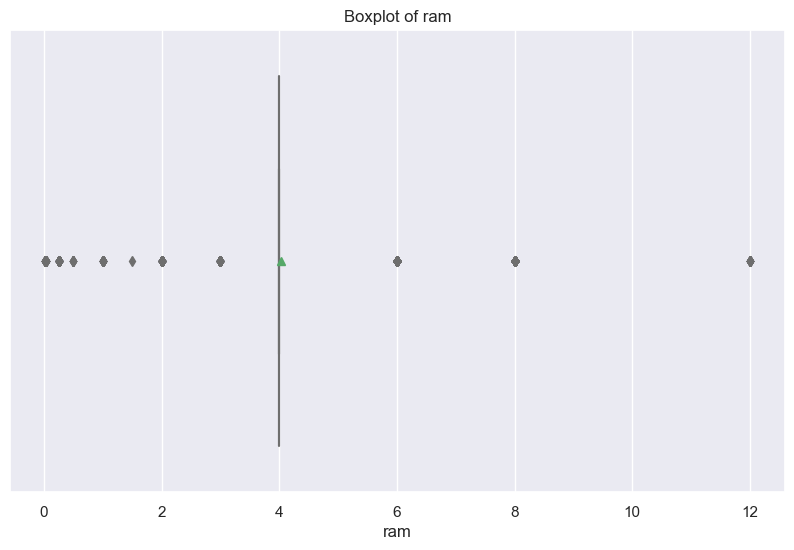

```python
# ram field univariate analysis
selected_column = 'ram'

#calculate univariate statistics
calculate_statistics(df,selected_column)

#show histogram for ram
histogram(df, selected_column)

#show boxplot for ram
boxplot(df,selected_column,in_showfliers=False,in_showlabels=False)
```

#### Observation

- The average RAM size is 4.036122 GB.
- The vast majority of devices have approximately for 4 GB with outliers on both ends.
- This may be an indication that RAM size may not be a strong influencer of price.

```
Discrete Statistics for battery

Mean              : 3133.402697
Mode              : 4000.0
Median            : 3000.0
Min               : 500.0
Max               : 9720.0
Standard Deviation: 1299.682844
Percentiles       :
0.250000   2100.000000
0.500000   3000.000000
0.750000   4000.000000
Name: battery, dtype: float64
```

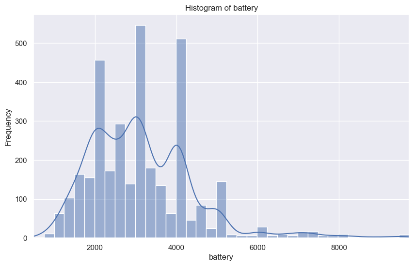

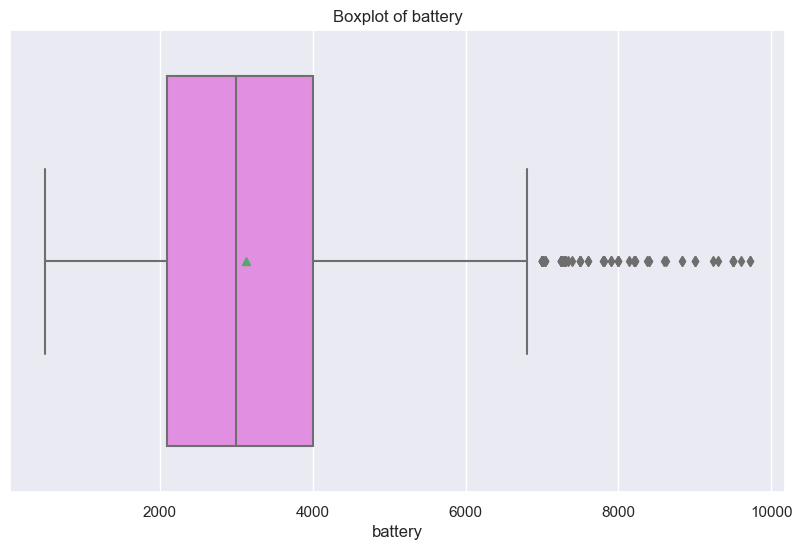

```python
# battery field univariate analysis
selected_column = 'battery'

#calculate univariate statistics
calculate_statistics(df,selected_column)

#show histogram for battery
histogram(df, selected_column)

#show boxplot for battery
boxplot(df,selected_column,in_showfliers=False,in_showlabels=False)
```

#### Observation

- The average energy capacity of the batteries is 3133.402697 mAh.
- The minimum energy capacity of the batteries is 500.0 mAh and the maximium is 9720.0 mAh.
- There are some outliers beyond the maximum whisker.

```
Discrete Statistics for weight

Mean              : 182.751871
Mode              : 150.0
Median            : 160.0
Min               : 69.0
Max               : 855.0
Standard Deviation: 88.413228
Percentiles       :
0.250000   142.000000
0.500000   160.000000
0.750000   185.000000
Name: weight, dtype: float64
```

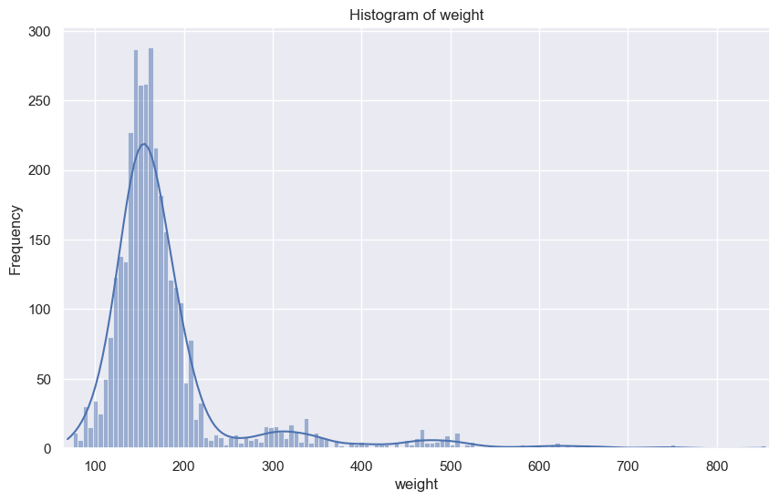

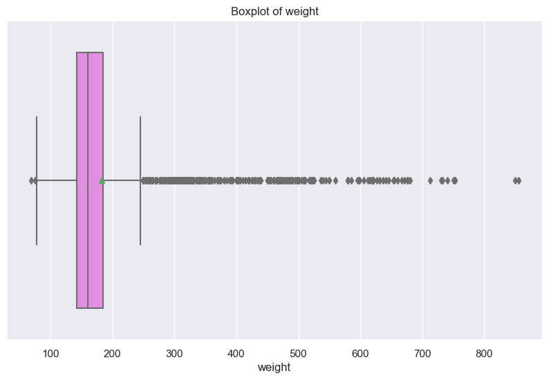

```python
# battery field univariate analysis
selected_column = 'weight'

#calculate univariate statistics
calculate_statistics(df,selected_column)

#show histogram for weight
histogram(df, selected_column)

#show boxplot for weight
boxplot(df,selected_column,in_showfliers=False,in_showlabels=False)
```

#### Observation

- The average weight of the batteries is 182.751871 g.
- The weight distribution is right skewed.
- There are outliers beyond the maximum value whisker.

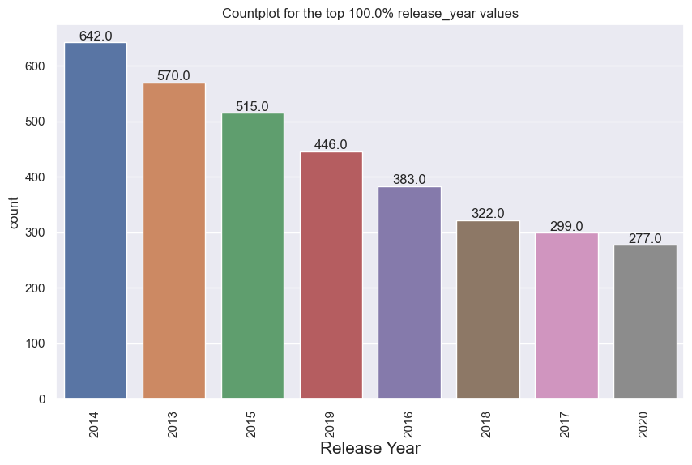

```
Number of Release Years: 8
```

```python
# release_year field univariate analysis

#Create histogram plot for the top groups
countplot(df,'release_year',show_perc=1.0,label_count=True)

#Print the total number of unique restaurants
print(f"Number of Release Years: {df['release_year'].nunique()}")
```

#### Observation

```
Discrete Statistics for days_used

Mean              : 674.869716
Mode              : 564
Median            : 690.5
Min               : 91
Max               : 1094
Standard Deviation: 248.580166
Percentiles       :
0.250000   533.500000
0.500000   690.500000
0.750000   868.750000
Name: days_used, dtype: float64
```

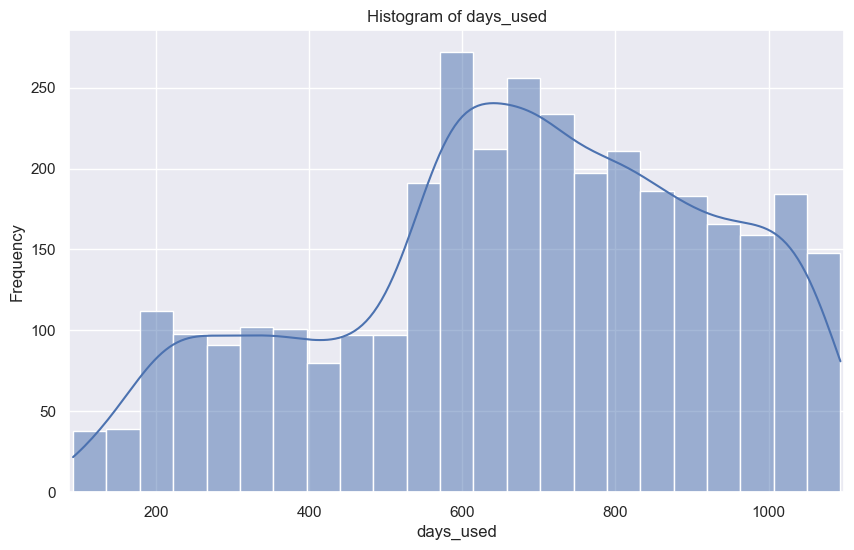

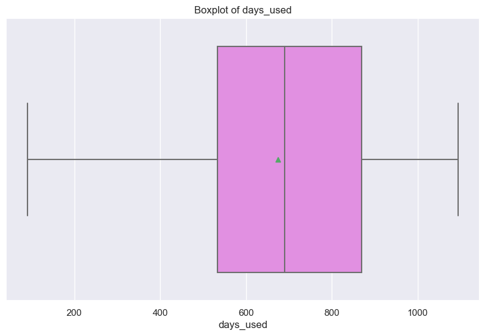

```python
# days_used field univariate analysis
selected_column = 'days_used'

#calculate univariate statistics
calculate_statistics(df,selected_column)

#show histogram for days_used
histogram(df, selected_column)

#show boxplot for days_used
boxplot(df,selected_column,in_showfliers=False,in_showlabels=False)
```

#### Observation

- The average number of days used is 674.869716 days (approximately, 1.85 yrs).
- The minimum number of days used is 91 and the maximum number of days used is 1094.

```
Discrete Statistics for normalized_new_price

Mean              : 5.233107
Mode              : 5.135739611790679
Median            : 5.2458918493708575
Min               : 2.9014215940827497
Max               : 7.847840659422009
Standard Deviation: 0.683637
Percentiles       :
0.250000   4.790342
0.500000   5.245892
0.750000   5.673718
Name: normalized_new_price, dtype: float64
```

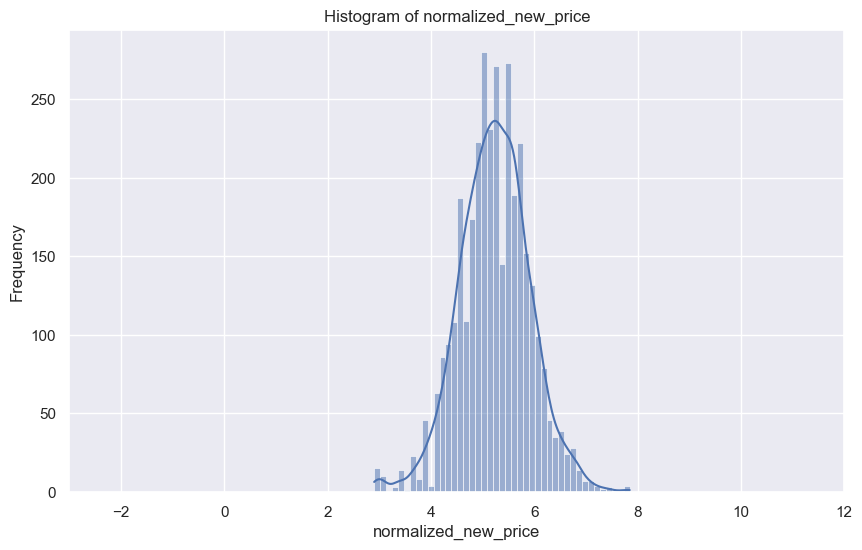

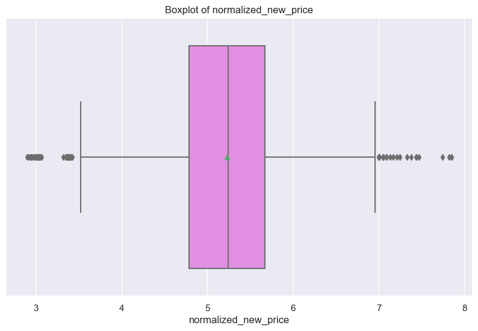

```python
# normalized_new_price field univariate analysis
selected_column = 'normalized_new_price'

#calculate univariate statistics
calculate_statistics(df,selected_column)

#show histogram for normalized_new_price
histogram(df, selected_column)

#show boxplot for normalized_new_price
boxplot(df,selected_column,in_showfliers=False,in_showlabels=False)
```

#### Observation

- The average normalized new price of a device is 5.233107 euros.
- The normalized_new_price data visually represents a normal distribution.
- There are outliers on both ends.

```
Discrete Statistics for normalized_used_price

Mean              : 4.364712
Mode              : 3.535145354171894
Median            : 4.405132623388357
Min               : 1.536867219599265
Max               : 6.619433001642933
Standard Deviation: 0.588914
Percentiles       :
0.250000   4.033931
0.500000   4.405133
0.750000   4.755700
Name: normalized_used_price, dtype: float64
```

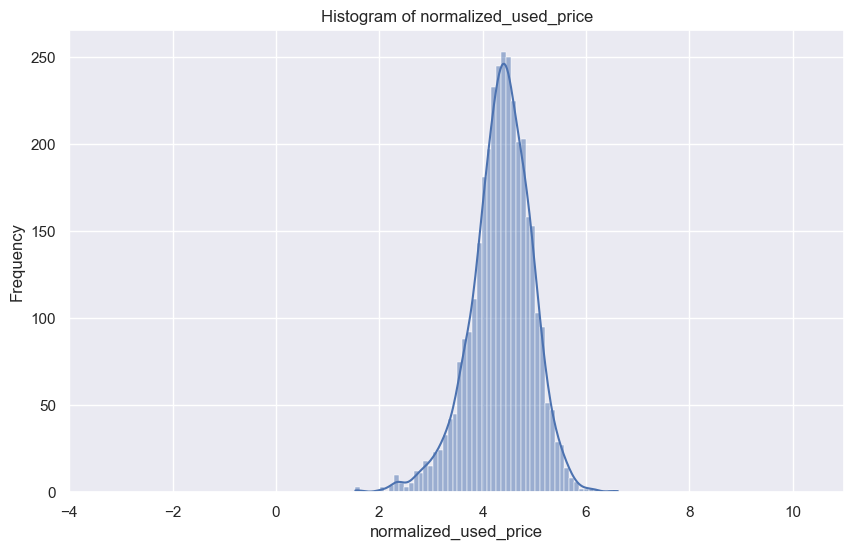

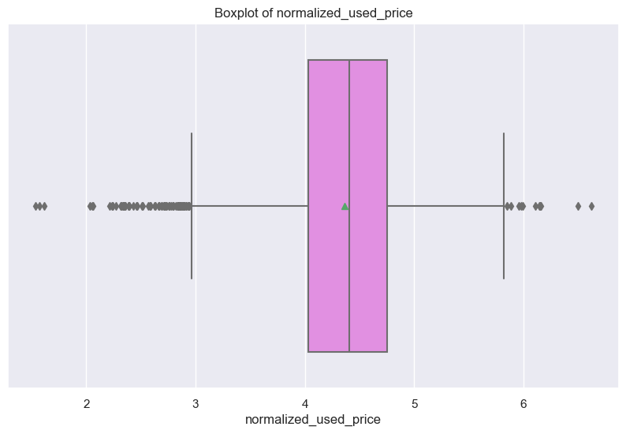

```python
# normalized_new_price field univariate analysis
selected_column = 'normalized_used_price'

#calculate univariate statistics
calculate_statistics(df,selected_column)

#show histogram for normalized_used_price
histogram(df, selected_column)

#show boxplot for normalized_used_price
boxplot(df,selected_column,in_showfliers=False,in_showlabels=False)
```

#### Observation

- The average normalized used price of a device is 4.364712 euros.
- The average normalized used price is about .868395 euros less than the average normalized new price.
- The normalized_new_price data visually represents a normal distribution.
- There are outliers on both ends.

### Bivariate Analysis

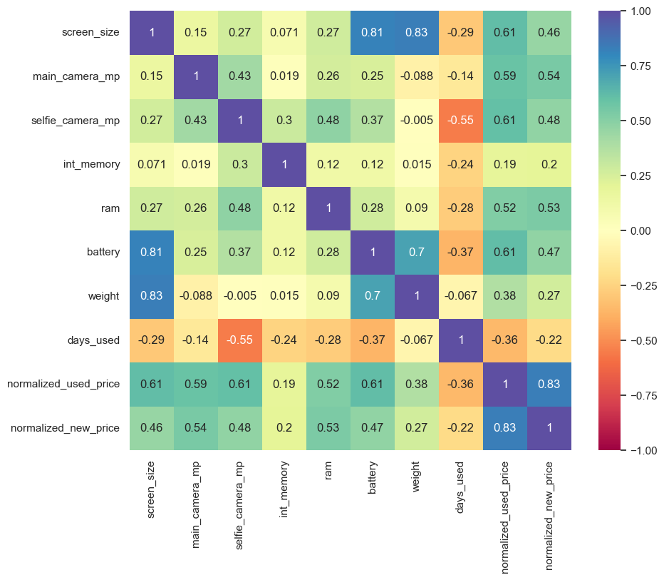

```python
# Get the list of columns that are numbers
col_list = df.select_dtypes(include=np.number).columns.tolist()

# dropping release_year as it's not really continuous in nature
col_list.remove("release_year")

# show a heatmap to look for any strong correlations between the number fields.
heatmap(df[col_list])
```

#### Observation

- There's a strong correlation between screen_size and the battery capacity and weight.
- There's a strong correlation between normalized_used_price and normalized_new_price.

### Questions

1. What does the distribution of normalized used device prices look like?

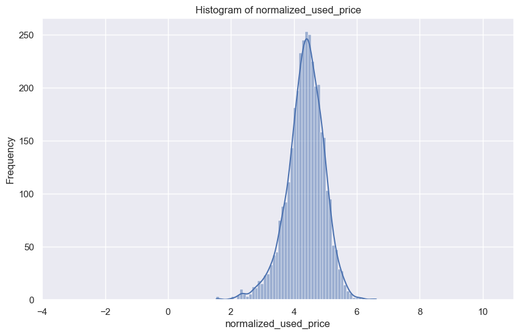

```python
#show histogram for normalized_used_price
histogram(df, 'normalized_used_price')
```

#### Observation

- From a visual perspective, the normalized_used_price has a normal distribution.
1. What percentage of the used device market is dominated by Android devices?

```python
# Get the number of android devices
android_count = df['os'].value_counts()['Android']

# Get the total number of devices
total_os_count = df['os'].value_counts().sum()

# Print the Android percentage value of the used device market.
print(F"Android devices make up {round((android_count/total_os_count)*100.0,2)}% of the used device market.")
```

```
Android devices make up 93.05% of the used device market.
```

1. The amount of RAM is important for the smooth functioning of a device. How does the amount of RAM vary with the brand?

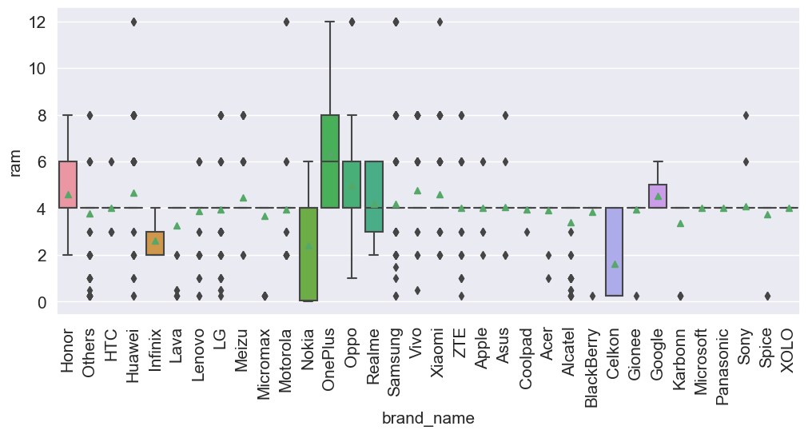

```python
# Plot a multi boxplot for brand_name vs ram
multi_boxplot (df, 'brand_name', 'ram')
```

#### Observation

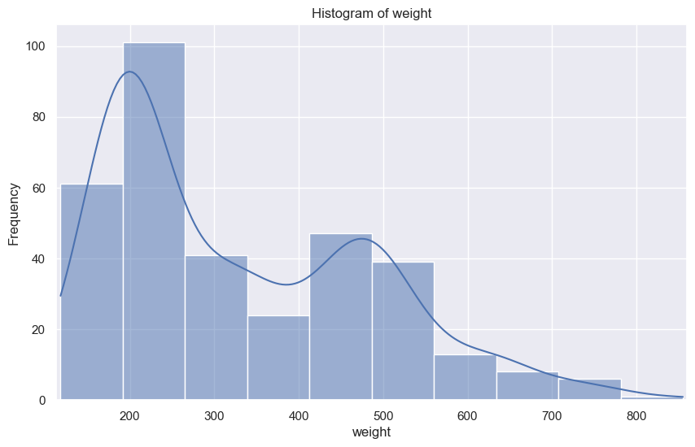

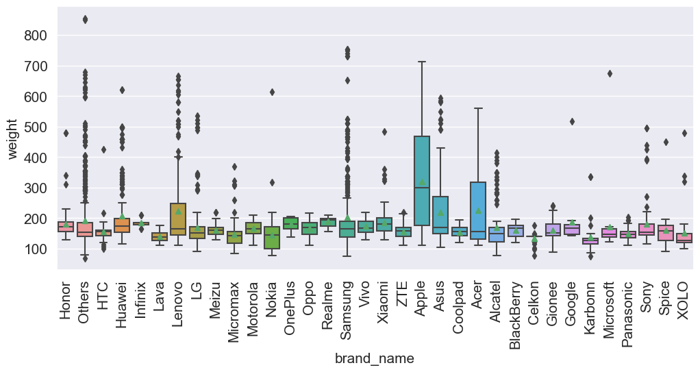

```python
large_batteries_df = df[df['battery'] > 4500]

histogram(large_batteries_df, 'weight', in_kde=True)

multi_boxplot (large_batteries_df, 'brand_name', 'weight')
```

```python
# Screen size is in centimeters.  The conversion ratio is 1 in = 2.54 cm.
large_screensize_df = df[df['screen_size'] > 6*2.54]

print (F"There are {large_screensize_df.shape[0]} phones with a screen size larger than 6 inches.")
```

```
There are 1099 phones with a screen size larger than 6 inches.
```

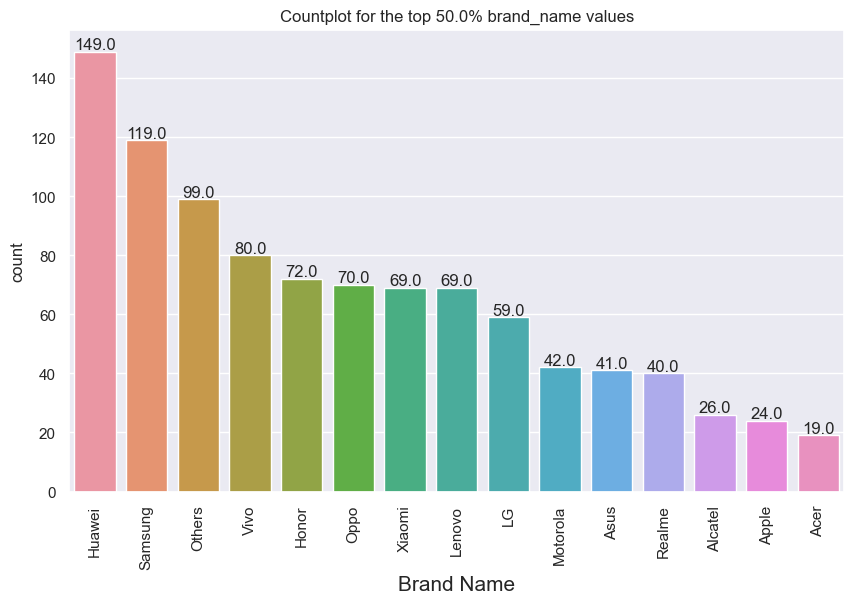

```
Number of brand names with a large screen size: 31
```

```python
#Create histogram plot for the top groups
countplot(large_screensize_df,'brand_name',show_perc=.5,label_count=True)

#Print the total number of unique restaurants
print(f"Number of brand names with a large screen size: {large_screensize_df['brand_name'].nunique()}")
```